# Activity: Graphical Exploration

Ziyuan Ye

Due Date: September 21, 2021

## Front Matter

Install supporting R packages with necessary functions and data sets. You will need to add `library(DataComputing)` to the code chunk. Note the line `rm(list = ls())` at the beginning of the code chunk, this will effectively reset your R environment which can help avoid bugs when an analysis gets more complicated.

```r
rm(list = ls())      # cleans up your R environment

# load packages
library(mosaic)
library(tidyverse)   # loads a group of useful packages including `ggplot2`
```

### Explore the `diamonds` data

*Task: Use R to produce one informative graphic of the `diamonds` data. The graphic should represent AT LEAST 3 variables. Write a few sentences to describe what we can learn from the graphic your have provided. (Note: please do NOT write your narrative inside the code chunk.)*

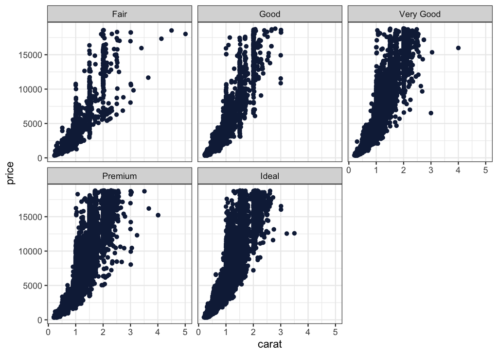

```r
# read `diamonds` data into R; it has been provided by the `ggplot2` package
data("diamonds", package = "ggplot2")

# add your code below for your one key data visualization
ggplot(diamonds) +
  aes(x = carat, y = price) +
  geom_point(shape = "circle", size = 1.5, colour = "#112446") +
  theme_bw() +
  facet_wrap(vars(cut))
```

The dataset represents 54000 diamonds in terms of different attributes. One case demonstrates one diamond with its attributes. For example, price means price in US dollars. Carat represents weight of the diamond. Cut represents the quality of the cut. My graph chooses carat, price, and cut as variables. I put carat as x-axis, price as y-axis, and cut as facet. The scatter plot graph shows the correlation between carat and price in terms of different cut. We can see the correlation is weakest while cut is fair.

### Explore the cereal data

*Task: Use R to produce one informative graphic of the `cereal.csv` data. The graphic should represent AT LEAST 3 variables. Write a few sentences to describe what we can learn from the graphic your have provided. (Note: please do NOT write your narrative inside the code chunk.)*

```r
# read CSV data set into R
CerealData <- readr::read_csv(file = "cereal.csv")
```

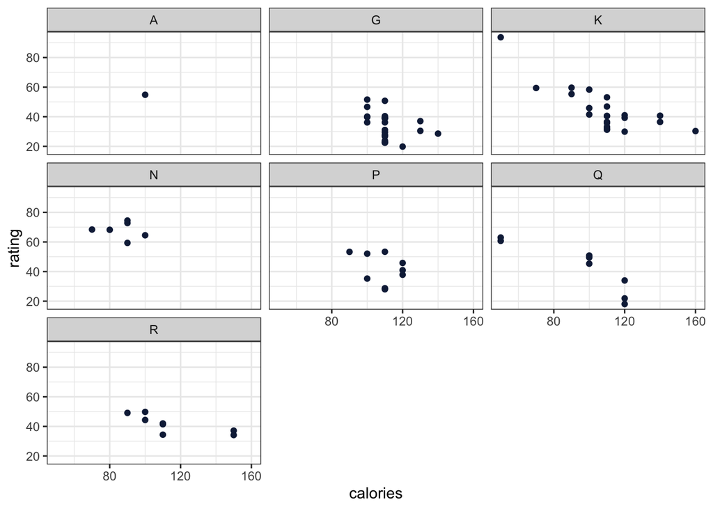

```r
# add your code below for your one key data visualization

ggplot(CerealData) +
  aes(x = calories, y = rating) +
  geom_point(shape = "circle", size = 1.5, colour = "#112446") +
  theme_bw() +
  facet_wrap(vars(mfr))
```

### Extension: programming style

The helper functions are great, but they produce ugly code. Clean up the `ggplot2` code that reproduces the required plots so that it aligns with the R Programming Style Guide Appendix in the *DataComputing* eBook https://dtkaplan.github.io/DataComputingEbook/.